# Flooding Leads to the Most Economic Damage, while Excessive Heat Leads to Most Deaths

Kathryn Fahnline

4/24/2021

## I. Data Processing

There were two options for loading the data: unzipping the file or reading directly from the zipped file. I decided to read directly from the zipped file.

```r
library(downloader)
fileUrl <- "https://d396qusza40orc.cloudfront.net/repdata%2Fdata%2FStormData.csv.bz2"
download.file(fileUrl, destfile = "noaa.csv.bz2", method="curl")
data <- read.csv("noaa.csv.bz2")
```

I wanted to break the analysis down by region, so I also downloaded a csv file with state codes created by KJ Healy. [fipscodes](https://github.com/kjhealy/fips-codes)[^3]

```r
fileUrl <- "https://raw.githubusercontent.com/kjhealy/fips-codes/master/state_fips_master.csv"
download.file(fileUrl, destfile = "state_codes.csv", method="curl")
state_codes <- read.csv("state_codes.csv")
```

#### Check out data and delete unnecessary columns

```r
library(dplyr)
str(data)
```

```
## 'data.frame':    902297 obs. of  37 variables:
##  $ STATE__   : num  1 1 1 1 1 1 1 1 1 1 ...
##  $ BGN_DATE  : chr  "4/18/1950 0:00:00" "4/18/1950 0:00:00" "2/20/1951 0:00:00" "6/8/1951 0:00:00" ...
##  $ BGN_TIME  : chr  "0130" "0145" "1600" "0900" ...
##  $ TIME_ZONE : chr  "CST" "CST" "CST" "CST" ...
##  $ COUNTY    : num  97 3 57 89 43 77 9 123 125 57 ...
##  $ COUNTYNAME: chr  "MOBILE" "BALDWIN" "FAYETTE" "MADISON" ...
##  $ STATE     : chr  "AL" "AL" "AL" "AL" ...
##  $ EVTYPE    : chr  "TORNADO" "TORNADO" "TORNADO" "TORNADO" ...
##  $ BGN_RANGE : num  0 0 0 0 0 0 0 0 0 0 ...
##  $ BGN_AZI   : chr  "" "" "" "" ...
##  $ BGN_LOCATI: chr  "" "" "" "" ...
##  $ END_DATE  : chr  "" "" "" "" ...
##  $ END_TIME  : chr  "" "" "" "" ...
##  $ COUNTY_END: num  0 0 0 0 0 0 0 0 0 0 ...
```

[output cut: 23 more lines]

```r
data <- select(data, c(STATE, BGN_DATE, EVTYPE, FATALITIES, INJURIES, PROPDMG, PROPDMGEXP, CROPDMG, CROPDMGEXP))
```

I only kept the columns of data that were necessary to determne which weather events had the greatest impact on economic damage and human health.

#### Filter data based on number of weather events in data set[^4]

From the NOAA website, I learned that starting in 1996, 48 event types are recorded in the Storm Events Database. Before 1996, only tornado (1950-present), thunderstorm, wind and hail (1955-present) were recorded.[Storm Data](https://www.ncdc.noaa.gov/stormevents/details.jsp) Because this assignment asks us to determine which events have the biggest effect on human health or largest economic impact, I have filtered for data set to only include records with the complete set of event data from 1996.

```r
library(lubridate)
data$year <- year(mdy_hms(data$BGN_DATE))
data<- data[data$year > 1995,]
```

#### Cleaning the event type names

The event names are not all coded in the same way, so I created a new variable, event, that has all lower case letters and standardized event names by making the following transformations:

- tolower was used to change the event names to lower case
- grepl was used to find the index of for all variations of a specific event type
- the index was used to replace all variations with the official name, as stated in the documentation.[Storm Data Event Table](https://d396qusza40orc.cloudfront.net/repdata%2Fpeer2_doc%2Fpd01016005curr.pdf)

```r
data$event <- tolower(data$EVTYPE)

official_event_names <- tolower(c("Astronomical Low Tide", "Avalanche,     Blizzard", "Coastal Flood","Cold/Wind Chill", "Debris Flow", "Dense Fog", "Dense Smoke", "Drought", "Dust Devil", "Dust Storm", "Excessive Heat", "Extreme Cold/Wind Chill", "Flash Flood", "Flood", "Frost/Freeze", "Funnel Cloud",  "Freezing Fog", "Hail", "Heat", "Heavy Rain", "Heavy Snow",  "High Surf", "High Wind", "Hurricane/Typhoon", "Ice Storm", "Lake-Effect-Snow", "Lakeshore Flood", "Lightning",  "Marine Hail", "Marine High Wind", "Marine Strong Wind", "Marine Thunderstorm Wind", "Rip Current", "Seiche", "Sleet",
 "Storm Surge/Tide", "Strong Wind", "Thunderstorm Wind", "Tornado", "Tropical Depression", "Tropical Storm",  "Tsunami", "Volcanic Ash", "Waterspout", "Wildfire",  "Winter Storm", "Winter Weather"))
```

```r
a <- grepl("ashfall", data$event)
c <- grepl("coastal flood", data$event)
cf <- grepl("cstl flood", data$event)
cd <- grepl("[Dd]ry", data$event)
d <- grepl("[Cc]old", data$event)
f <- grepl("flash", data$event)
fz <- grepl("freeze", data$event)
fr <- grepl("freezing rain", data$event)
h <- grepl("hail", data$event)
hr <- grepl("hurricane", data$event)
l <- grepl("lake effect", data$event)
rp <- grepl("record precipitation", data$event)
rf <- grepl("rainfall", data$event)
r <- grepl("rain", data$event)
s <- grepl("snow", data$event)
sg <- grepl("surge", data$event)
sf <- grepl("surf", data$event)
t <- grepl("typhoon", data$event)
ts <- grepl("tstm", data$event)
wc <- grepl("windchill", data$event)
```

```r
library(stringr)
data$event[a == TRUE] <- "volcanic ash"
data$event[c == TRUE | cf == TRUE] <- "coastal flood"
data$event[c == TRUE | wc == TRUE] <- "extreme cold/wind chill"
data$event[d== TRUE] <- "drought"
data$event[f == TRUE] <- "flash flood"
data$event[rf==TRUE | rp==TRUE | r==TRUE ] <- "heavy rain"
data$event[fr == TRUE] <- "sleet"
data$event[fz == TRUE] <- "frost/freeze"
data$event[h == TRUE] <- "hail"
data$event[l == TRUE] <- "lake-effect"
data$event[sf == TRUE] <- "high surf"
data$event[s == TRUE] <- "heavy snow"
data$event[sg == TRUE] <- "storm surge/tide"
data$event[t == TRUE | hr == TRUE] <- "hurricane/typhoon"
data$event[ts == TRUE] <- "tsunami"
data$event <- str_replace(data$event, "strong winds", "strong wind")
data$event <- str_replace(data$event, "rip currents", "rip current")
data$event <- str_replace_all(data$event, "high wind (g40)", "high wind")
data$event <- str_replace_all(data$event, "dust devel", "dust devil")
data$event <- str_replace_all(data$event, "ice fog", "freezing fog")
```

There are some event names that are are not clearly in one of the standarized event types. I decided to delete these instances from the data base. I checked to see which events did not match the official list after the above standardization.

```r
library(dplyr)
bad_names <- setdiff(data$event, official_event_names)
bn <- length(bad_names)
data <- filter(data, event %in% official_event_names)
```

#### Cleaning the CROPDMG and PROPDMG variables

I made the following tranformations to the CROPDMG and PROPDMG.[^5]

- Filter data set to exclude rows w/ either missing data for PROPDMGEXP or CROPDMGEXP
- Created a function to adjust for different units in CROPDMGEXP and PROPDMGEXP

```r
econ_df <- data[data$CROPDMGEXP != "" |
                        data$PROPDMGEXP != "", ]
```

- Function to adjust for different units in CROPDMGEXP and PROPDMGEXP

```r
transform <- function (x, y) {

        if (x == "H" | x == "h")
                {y <- y * 10
        } else if (x == "K" | x == "k")
                {y <- y * 10^3
        } else if (x == "M" | x == "m")
                {y <- y * 10^6
        } else if (x == "B" | x == "b")
                {y <- y * 10^9
        } else if (x == "-" | x == "?")
                 {y <- 0
        }
        y
}
```

- Use **transform** to adjust CROPDMG and PROPDMG to account for the different units in the original data base.

```r
econ_df$units_adj_cropdmg <- mapply(transform,
                econ_df$CROPDMGEXP, econ_df$CROPDMG)
econ_df$units_adj_propdmg <- mapply(transform,
                econ_df$PROPDMGEXP, econ_df$PROPDMG)
econ_length <- nrow(econ_df)
```

After all of the cleaning, the econ_df data set contains 377025 observations.

#### Create a factor variable for the region of the country

- There are 50 states plus the DC and 5 territories.hud.gov

```r
states_territories <- c(state_codes$state_abbr, "AS", "GU", "PR", "VI", "MP")
length <- length(unique(econ_df$STATE))
```

Therefore, there should be 56 unique state codes. However, there are 69 unique codes in the STATE variable. There is no way to determine what code should have been entered, so when I do the regional analysis I have filtered out the observations associated with the 13 invalid state codes plus DC when creating the table on economic damage by region.[^6]

- create a factor variable for the region of the country

```r
region <- c(state_codes$region_name, "Territory",
            "Territory", "Territory","Territory", "Territory")
econ_df$region <- factor(econ_df$STATE, levels = states_territories,
                         labels = region)
```

## II. Results

### Economic Impact of Storms by Event Type

We were asked to explore which weather event type causes the most economic damage. To answer this question, I first found the total property and crop damage for each event type and ranked by total property damage. I then found the top three destructive weather types by region of the country.

- Create a table showing the total property and crop damage by year for each event type and rank to find the 10 most expensive types. I used the package gt to create my tables. The documentation for this package can be found here.[https://gt.rstudio.com/articles/intro-creating-gt-tables.html]

```r
library(gt)
library(dplyr)
tab = econ_df %>%
        tibble() %>%
        group_by(event) %>%
        summarize(total_property_damage = sum(units_adj_propdmg/10^6),
                  total_crop_damage = sum(units_adj_cropdmg/10^6)) %>%
        arrange(desc(total_property_damage)) %>%
        top_n(10) %>%
        gt(rowname_col = "event") %>%
        tab_header(
        title = "Table 1:  Ten Most Costly Weather Events (Millions)",
        subtitle = "1996-2011")  %>%
        cols_align(align = "left") %>%
        tab_source_note(source_note = "Source:  NOAA Storm Data")  %>%
        fmt_currency(
                columns = vars(total_property_damage, total_crop_damage),
                currency = "USD", decimals = 0)  %>%
        cols_label(
                event = "Event",
                total_property_damage= "Total Property Damage",
                total_crop_damage = "Total Crop Damage"
                ) %>%
        opt_row_striping(row_striping = TRUE) %>%
        opt_table_outline() %>%
        tab_options(
                heading.background.color = "#85C1E9",
                row.striping.background_color = "#EBF5FB",
                column_labels.background.color = "#D6EAF8"
        )
print(tab)
```

Table 1: Ten Most Costly Weather Events (Millions)

1996-2011

|  | Total Property Damage | Total Crop Damage |
| --- | --- | --- |
| flood | $143,945 | $4,975 |
| hurricane/typhoon | $81,719 | $5,350 |
| flash flood | $15,222 | $1,335 |
| hail | $14,595 | $2,497 |
| tropical storm | $7,642 | $678 |
| high wind | $5,248 | $634 |
| tsunami | $4,680 | $619 |
| drought | $1,077 | $14,707 |
| heavy rain | $585 | $738 |
| frost/freeze | $19 | $1,327 |

Source: NOAA Storm Data

The most economic damage was cased by floods, followed by hurricanes/typhoons. Droughts led to the most crop damage.

#### Create plot of yearly economic damage by the top 5 most destructive weather event types.

```r
library(dplyr)

top_five_damage <- econ_df %>% group_by(event) %>%
        summarize(total_property_damage = sum(units_adj_propdmg/10^6),
                  total_crop_damage = sum(units_adj_cropdmg/10^6)) %>%
          arrange(desc(total_property_damage, total_crop_damage)) %>% top_n(5)
```

```r
##create new data frame to plot, grouped by both year and event
df <- econ_df %>% group_by(year, event) %>%
        summarize(total_property_damage = sum(units_adj_propdmg)/10^6,
                  total_crop_damage = sum(units_adj_cropdmg)/10^6)
plot <- filter(df, event %in% top_five_damage$event)
plot$event <- as.factor(plot$event)
```

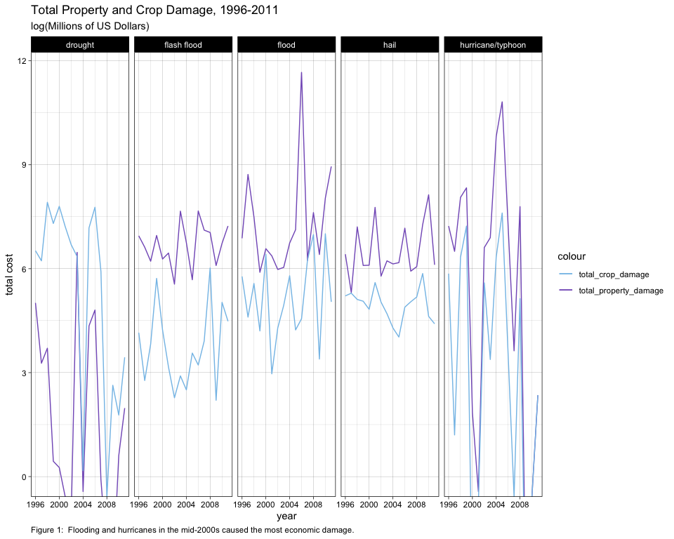

```r
library(ggplot2)

m <- max(plot$total_property_damage)
d <- ggplot(data=plot, aes(year)) +
  geom_line(aes(y=log(total_property_damage),
                colour="total_property_damage")) +                geom_line(aes(y=log(total_crop_damage),                                                       colour = "total_crop_damage")) +
        labs(y="total cost",
        title="Total Property and Crop Damage, 1996-2011",
        subtitle=("log(Millions of US Dollars)"),
        caption = "Figure 1:  Flooding and hurricanes in the mid-2000s caused the most economic damage.") +
        facet_grid(.~ event) +
        coord_cartesian(ylim=c(0, log(m)))
d + scale_colour_manual(values = c("#85C1E9", "#845EC2")) + theme_linedraw() +     theme(plot.caption = element_text(hjust = 0)
         )
```

This plot reveals that while there is a great deal of yearly variation, flooding and hurricanes caused a huge amount of economic damage in the mid-2000s.

#### Filter data set to remove invalid state codes

I waited until after I had investigated the effects on a national level before subsetting the data set for valid state codes.

```r
econ_df <- econ_df[econ_df$STATE %in% states_territories, ]
```

- The gt package is fairly new, so I read the very helpful tutorial at [towarddatascience.com](https://towardsdatascience.com/exploring-the-gt-grammar-of-tables-package-in-r-7fff9d0b40cd) to create the table on regional economic effects of different weather events.
- group by region and event and find total property and crop damage
- arrange in descending order by total property damage and report top 3

```r
library(gt)
library(dplyr)
tab1 = econ_df %>%
        tibble() %>%
        group_by(region, event) %>%
        summarize(total_property_damage =
                          sum(units_adj_propdmg)/10^6,
                  total_crop_damage =
                          sum(units_adj_cropdmg)/10^6)%>%
        arrange(desc(total_property_damage, total_crop_damage)) %>% top_n(3)          %>%
        gt(rowname_col = "event") %>%
        tab_header(
        title = "Table 2:  Most Costly Weather Events by Region (Millions)",
        subtitle = "1996-2011")  %>%
        cols_align(align = "left") %>%
        tab_source_note(source_note = "Source:  NOAA Storm Data")  %>%
        fmt_currency(
                columns = vars(total_property_damage, total_crop_damage),
                currency = "USD", decimals = 0)  %>%
        cols_label(
                total_property_damage = "Total Property Damage",
                total_crop_damage = "Total Crop Damage"
                ) %>%
        opt_row_striping(row_striping = TRUE) %>%
        opt_table_outline() %>%
        tab_options(
                heading.background.color = "#85C1E9",
                row_group.background.color = "#EBF5FB",
                column_labels.background.color = "#D6EAF8"
        )
print(tab1)
```

Table 2: Most Costly Weather Events by Region (Millions)

1996-2011

|  | Total Property Damage | Total Crop Damage |
| --- | --- | --- |
| South |  |  |
| hurricane/typhoon | $78,941 | $4,793 |
| flood | $10,216 | $905 |
| drought | $399 | $10,007 |
| Midwest |  |  |
| flood | $8,513 | $3,681 |
| hail | $6,170 | $1,466 |
| drought | $655 | $3,155 |
| Northeast |  |  |
| flash flood | $4,311 | $20 |
| hail | $15 | $103 |
| drought | $1 | $702 |
| Territory |  |  |
| hurricane/typhoon | $2,777 | $557 |
| flood | $116 | $48 |
| tropical storm | $101 | $104 |
| West |  |  |
| heavy rain | $517 | $717 |
| drought | $17 | $844 |
| frost/freeze | $6 | $503 |

Source: NOAA Storm Data

Hurricane/typhoons and flooding in the South led to the greatest amount of economic damage.

### Human Impact of Weather Events

We were asked to explore which weather event type causes the most harm to human health. To answer this question, I first found the total number of fatalities and injuries for each event type. I then found the top ten most impactful weather types.

#### Total US Health Impact

- Find total fatalities and injuries by year for each event type and rank to find the 10 most expensive types.

```r
health <- data %>% group_by(event) %>%
        summarize(total_fatalities = sum(FATALITIES),
                  total_injuries = sum(INJURIES) )

health <- filter(health, event %in% official_event_names)
health_table <- health %>%
        arrange(desc(total_fatalities, total_injuries)) %>% top_n(10)
library(gt)
ht_tbl <- data %>%
          tibble() %>%
          group_by(event) %>%
          summarize(total_fatalities = sum(FATALITIES),
                  total_injuries = sum(INJURIES)) %>%
          arrange(desc(total_fatalities)) %>%
          top_n(10) %>%
          gt(rowname_col = "event") %>%
          tab_header(
            title = "Table 3:  Weather Types Ranked by Impact on Human Health",
            subtitle = "1996-2001") %>%
            cols_align(align = "left") %>%
            tab_source_note(source_note = "Source:  NOAA Storm Data") %>%
            cols_label(
              event = "Event",
              total_fatalities = "Total Fatalities",
              total_injuries = "Total Injuries"
            )  %>%
           opt_row_striping(row_striping = TRUE) %>%
           opt_table_outline() %>%
           tab_options(
             heading.background.color = "#85C1E9",
             row.striping.background_color = "EBF5FB",
             column_labels.background.color = "#D6EAF8"
            )
print(ht_tbl)
```

Table 3: Weather Types Ranked by Impact on Human Health

|  | Total Fatalities | Total Injuries |
| --- | --- | --- |
| excessive heat | 1797 | 6391 |
| tornado | 1511 | 20667 |
| flash flood | 887 | 1674 |
| lightning | 651 | 4141 |
| flood | 414 | 6758 |
| tsunami | 289 | 3866 |
| heat | 237 | 1222 |
| winter storm | 191 | 1292 |
| thunderstorm wind | 130 | 1400 |
| hurricane/typhoon | 125 | 1328 |

Source: NOAA Storm Data

According to the table, excessive heat leads to the most deaths, while tornadoes lead to the most injuries.

#### Regional health effects

```r
data$region <- factor(data$STATE, levels = states_territories,
                         labels = region)

health_data <- data[data$STATE %in% states_territories, ]
```

```r
library(gt)
library(dplyr)
tab1 = health_data %>%
        tibble() %>%
        group_by(region, event) %>%
        summarize(total_fatalities = sum(FATALITIES),
                  total_injuries = sum(INJURIES)) %>%
        arrange(desc(total_fatalities)) %>% top_n(3) %>%
        gt(rowname_col = "event" ) %>%
        tab_header(
        title = "Table 4:  Health Effects of Weather Events by Region",
        subtitle = "1996-2011")  %>%
        cols_align(align = "left") %>%
        tab_source_note(source_note = "Source:  NOAA Storm Data")  %>%
        cols_label(
                event = "Event",
                total_fatalities = "Total Fatalities",
                total_injuries = "Total Injuries"
                ) %>%
        opt_row_striping(row_striping = TRUE) %>%
        opt_table_outline() %>%
        tab_options(
                heading.background.color = "#85C1E9",
                row_group.background.color = "#EBF5FB",
                column_labels.background.color = "#D6EAF8"
        )
print(tab1)
```

Table 4: Health Effects of Weather Events by Region

1996-2011

|  | Total Fatalities | Total Injuries |
| --- | --- | --- |
| South |  |  |
| tornado | 1089 | 14399 |
| lightning | 354 | 2054 |
| flood | 173 | 6379 |
| Midwest |  |  |
| excessive heat | 594 | 4232 |
| tornado | 397 | 5247 |
| tsunami | 82 | 1368 |
| Northeast |  |  |
| excessive heat | 424 | 621 |
| lightning | 60 | 834 |
| tornado | 15 | 720 |
| West |  |  |
| lightning | 113 | 578 |
| winter storm | 85 | 685 |
| wildfire | 44 | 696 |
| Territory |  |  |
| rip current | 54 | 58 |
| tsunami | 32 | 132 |
| hurricane/typhoon | 22 | 360 |

Source: NOAA Storm Data

```r
midwest_tsunami <- filter(data, region == "Midwest" & event == "tsunami")
mwt <- filter(data, data$region == "Midwest" & data$event == "tsunami" & data$FATALITIES > 0)
print(head(mwt))
```

```
##   STATE          BGN_DATE    EVTYPE FATALITIES INJURIES PROPDMG PROPDMGEXP
## 1    IN 4/20/1996 0:00:00 TSTM WIND          2        0      50          K
## 2    MO  8/4/1996 0:00:00 TSTM WIND          3        6       0
## 3    MO  8/4/1996 0:00:00 TSTM WIND          1        0       0
## 4    NE  8/6/1996 0:00:00 TSTM WIND          1        0       0
## 5    OH 4/29/1996 0:00:00 TSTM WIND          1        0     300          K
## 6    OH 4/12/1996 0:00:00 TSTM WIND          1        1       1          M
##   CROPDMG CROPDMGEXP year   event  region
## 1       0            1996 tsunami Midwest
## 2       0            1996 tsunami Midwest
## 3       0            1996 tsunami Midwest
## 4       0            1996 tsunami Midwest
## 5       0            1996 tsunami Midwest
## 6       0            1996 tsunami Midwest
```

#### Plot Fatalities and Injuries for weather events by year

- Create a new data frame to plot deaths associated with different storm types.

```r
top_health <- filter(health, event %in% official_event_names) %>%
          arrange(desc(total_fatalities, total_injuries)) %>% top_n(5)
```

```r
##create new data frame to plot
df2 <- data %>% group_by(year, event) %>%
        summarize(total_fatalities = sum(FATALITIES),
                  total_injuries = sum(INJURIES))
plot2 <- filter(df2, event %in% top_health$event)
plot2$event <- as.factor(plot2$event)

#plot <- filter(df, event %in% top_damage$event)
f<- max(plot2$total_fatalities)

g <- ggplot(data=plot2, aes(x=year)) +
       geom_col(aes(y=total_fatalities, fill=event)) +
       labs(title="Total Fatalties by Weather Event Type, 1996-2011",
       y="total number of persons",
       caption="Figure 2:  Excessive heat consistently causes a lot of yearly deaths, but tornadoes led to the most deaths in 2011.")
       coord_cartesian(ylim=c(0, f))
```

[output not shown]

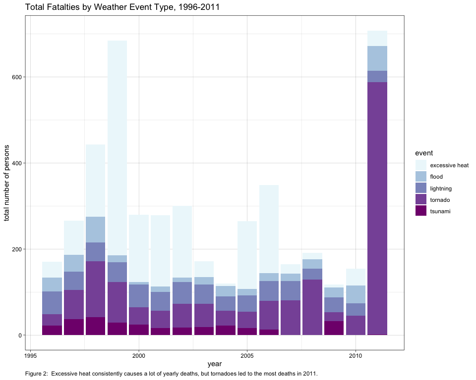

```r
g + scale_fill_brewer(palette="BuPu") + theme_linedraw() + theme(plot.caption        = element_text(hjust = 0))
```

- Plot total injuries by weather type event.

```r
#plot <- filter(df, event %in% top_damage$event)
i<- max(plot2$total_injuries)

h <- ggplot(data=plot2, aes(x=year)) +
       geom_col(aes(y=total_injuries, fill=event)) +
       labs(title="Total Injuries by Weather Event Type, 1996-2011",
       y="total number of persons",
       caption="Figure 3:  While tornadoes generally cause the most injuries, flooding in 1998 led to a spike in injuries.")
       coord_cartesian(ylim=c(0, i))
```

[output not shown]

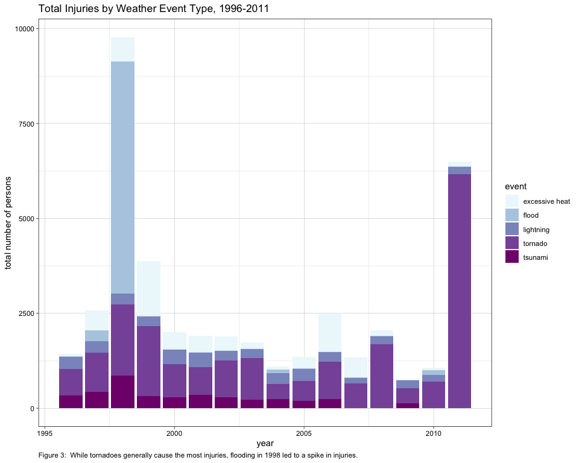

```r
h + scale_fill_brewer(palette="BuPu") + theme_linedraw() + theme(plot.caption        = element_text(hjust = 0))
```

```r
##h + theme_bw()
```

Figures 2 and 3 show that there is a great deal of yearly variation in the health effects from different weather events.For example, there was a spike in deaths from excessive heat in 1999 and a large number of deaths from tornadoes in 2011. Likewise, there was a large number of injuries due to flooding in 1998 and a large number of injuries due to tornadoes in 2011.

## Conclusion

This was a very interesting exercise. I learned that at a national level, flooding causes the most economic damage, while excessive heat leads to the most deaths overall. However, the economic and health impacts associated with different weather events vary greatly from year to year and by region.